# Variation Analysis & ICU Mortality

Lecture 9 vignette

Author

Causal Inference — STATS 420

1. How much of an observed group disparity is direct, mediated, or induced by differences in baseline covariates?
2. Do these pathways interact?
3. How does the direct effect vary across age and admission type?

The analysis compares patients recorded as Caucasian and African American in MIMIC-IV.

# 1 ICU mortality data

We consider each patient’s first ICU admission. The outcome is in-hospital death, and the measured clinical variables are:

- the SOFA score during the first 24 hours;
- admission diagnosis;
- age and sex;
- Charlson comorbidity index;
- worst lactate, PaO2/FiO2, and AST during the first 24 hours.

Missing clinical measurements were replaced by the same normal or reference values as in the original analysis.

```r
dat <- as.data.table(
  arrow::read_parquet(file.path("..", "data", "icu-mortality.parquet"))
)

show_cols <- c(
  "majority", "age", "acu_24", "diag", "charlson",
  "lact_24", "pafi_24", "ast_24", "death"
)
dat[1:6, ..show_cols]
```

| majority | age | acu_24 | diag | charlson | lact_24 | pafi_24 | ast_24 | death |
| --- | --- | --- | --- | --- | --- | --- | --- | --- |
| 1 | 61 | 3 | TRAUM | 0 | 1.7 | 430.0000 | 20 | FALSE |
| 1 | 40 | 3 | MED | 1 | 1.8 | 361.9048 | 23 | FALSE |
| 1 | 56 | 11 | MED | 1 | 1.7 | 466.6667 | 114 | FALSE |
| 1 | 68 | 3 | NMED | 0 | 1.0 | 500.0000 | 20 | FALSE |
| 1 | 43 | 2 | SURG | 1 | 0.7 | 535.0000 | 36 | FALSE |
| 1 | 72 | 4 | CSURG | 0 | 1.0 | 240.0000 | 20 | FALSE |

Let $X=1$ denote the majority group (Caucasian) and $X=0$ the minority group (African-American). Let $Y=1$ denote death. We assign age to the baseline covariates $Z$ and the clinical variables to the mediator set $W$:

```r
X <- "majority"
Z <- "age"
W <- c("acu_24", "diag", "charlson", "lact_24", "pafi_24", "ast_24")
Y <- "death"

data.frame(
  Role = c("Group", "Confounders", "Mediators", "Outcome"),
  Variables = c(X, Z, paste(W, collapse = ", "), Y)
)
```

| Role | Variables |
| --- | --- |
| Group | majority |
| Confounders | age |
| Mediators | acu_24, diag, charlson, lact_24, pafi_24, ast_24 |
| Outcome | death |

# 2 Decomposing the observed disparity

The total variation compares observed mortality between the two groups:

$$\begin{align}
\operatorname{TV}
&=P(Y=1\mid X=1)-P(Y=1\mid X=0).
\end{align}$$

The `faircause` decomposition separates this contrast into a counterfactual direct effect, an indirect effect through $W$, and a spurious component due to the different distribution of $Z$. Under the reverse-transition sign convention used in the course,

$$\begin{align}
\operatorname{TV}
&=\operatorname{DE}-\operatorname{IE}_{\mathrm{rev}}
-\operatorname{SE}_{\mathrm{rev}}.
\end{align}$$

```r
fcb <- fairness_cookbook(
  data = dat,
  X = X,
  Z = Z,
  W = W,
  Y = Y,
  x0 = 0,
  x1 = 1
)
```

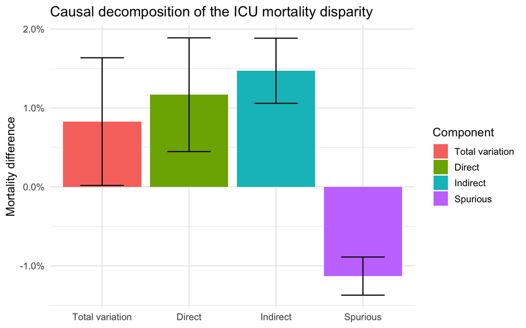

Estimated components of the mortality disparity.

| Component | Estimate | 95% interval |
| --- | --- | --- |
| Total variation | 0.83% | [0.02%, 1.64%] |
| Direct effect | 1.17% | [0.45%, 1.89%] |
| Indirect effect (reverse) | 1.47% | [1.06%, 1.88%] |
| Spurious effect (reverse) | -1.13% | [-1.37%, -0.89%] |

The decomposition motivates a closer look at all three sources of variation.

# 3 Understanding the components

## 3.1 Spurious component: age distributions

The two groups have different age distributions. Because age is associated with mortality and clinical severity, this difference contributes to the observed comparison even without changing group membership or mediators.

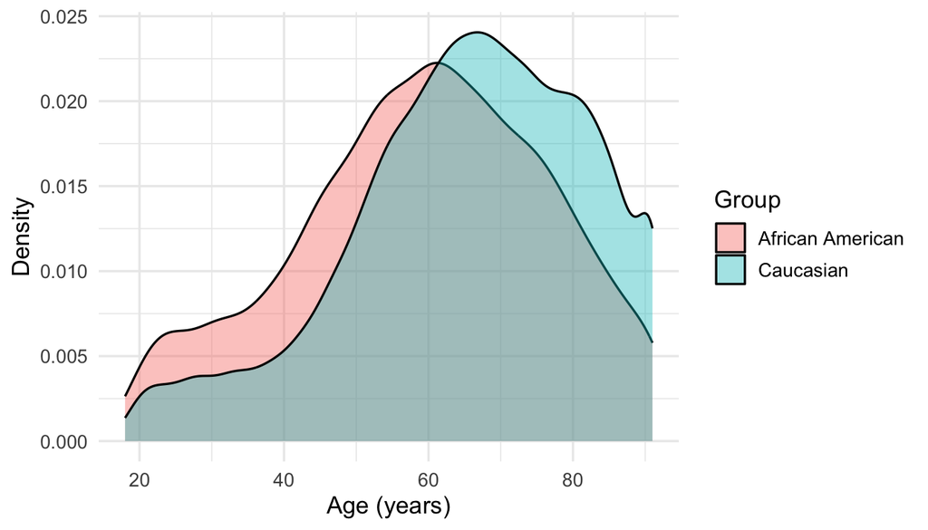

Minority patients in this ICU cohort are younger on average. A marginal comparison of downstream clinical variables would therefore mix group differences with age differences.

## 3.2 Indirect component: age-adjusted mediators

To compare mediator distributions at a common age distribution, we use Monte Carlo standardization. We sample one target age distribution and, within each group, resample patients of the corresponding rounded age. The result preserves the group-specific conditional distribution $P(W\mid X,Z)$ while making the marginal distribution of age the same in both groups.

```r
mc_age_adjust <- function(data, n_per_group = 100000) {
  d <- copy(data)
  d[, age_round := as.integer(round(age))]

  ages_0 <- unique(d[majority == 0, age_round])
  ages_1 <- unique(d[majority == 1, age_round])
  common_ages <- intersect(ages_0, ages_1)

  target_age <- sample(
    d[age_round %in% common_ages, age_round],
    n_per_group,
    replace = TRUE
  )

  standardized <- lapply(0:1, function(group) {
    selected_rows <- unlist(lapply(unique(target_age), function(age_value) {
      candidates <- which(d$majority == group & d$age_round == age_value)
      sample(candidates, sum(target_age == age_value), replace = TRUE)
    }))
    d[selected_rows]
  })

  rbindlist(standardized)
}

adj_dat <- mc_age_adjust(dat)
```

We first inspect the Charlson comorbidity distribution after standardizing age.

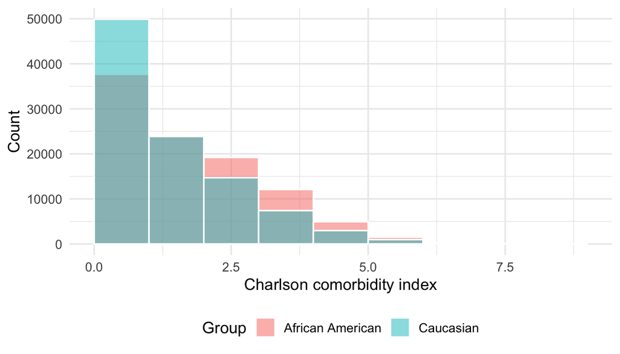

We also compare the age-standardized probability of a medical admission.

```r
medical_codes <- c("CMED", "MED", "NMED", "OMED")
medical_summary <- adj_dat[, .(
  `Medical admission` = pct(mean(diag %in% medical_codes), 1)
), by = Group]

show_table(
  medical_summary,
  "Age-standardized proportion of medical admissions.",
  align = c("l", "c")
)
```

Age-standardized proportion of medical admissions.

| Group | Medical admission |
| --- | --- |
| African American | 76.2% |
| Caucasian | 60.2% |

After age standardization, minority patients have higher Charlson scores and are more likely to have a medical rather than surgical admission. These clinical differences help explain the mediated component of the disparity.

## 3.3 Interaction testing

The decomposition of the TV is additive, but requires reverse transitions. However, in the absence of interactions, this is not needed. For example, if the outcome mechanism has no component depending jointly on $X$ and $W$, it can be written as

$$\begin{align}
f_Y(X,Z,W,U_Y)
&=f_Y^{(1)}(X,Z,U_Y)+f_Y^{(2)}(Z,W,U_Y).
\end{align}$$

In that case, reversing the transition changes the sign—but not the magnitude— of the direct effect:

$$\begin{align}
\operatorname{x\text{-}DE}_{x_0,x_1}
&=-\operatorname{x\text{-}DE}_{x_1,x_0}.
\end{align}$$

A failure of this antisymmetry indicates **direct–indirect interaction**. We test this and the remaining pathway interactions using `intertest`.

```r
set.seed(4209)
interaction_fit <- intertest::inter_test(
  data = dat[, c(X, Z, W, Y), with = FALSE],
  X = X,
  Z = Z,
  W = W,
  Y = Y,
  scale = "difference",
  nthread = 1
)
```

Tests of interaction among the direct, indirect, and selection pathways.

| Interaction | Estimate | Standard error | p-value |
| --- | --- | --- | --- |
| TE × SE | 0.18% | 0.14% | 0.185 |
| DE × IE | 0.58% | 0.17% | <0.001 |
| DE × SE | -0.21% | 0.14% | 0.115 |
| IE × SE | 0.34% | 0.09% | <0.001 |
| DE × IE × SE | -0.05% | 0.08% | 0.533 |

Small p-values indicate departures from an additive pathway decomposition. These are global tests: they tell us whether a component varies with another pathway, but not where that variation occurs. Conditional effects provide the next, more local view.

## 3.4 Direct component: conditional effect variation

The overall direct effect can itself vary. We estimate the direct effect conditional on an event $E$ defined by age group and admission type:

$$\begin{align}
\operatorname{DE}(E)
&=\mathbb{E}[Y_{x_1,W_{x_0}}-Y_{{x_0},W_{x_0}}\mid E].
\end{align}$$

The project-local helpers implement the required estimation procedure.

Admission diagnoses are grouped into medical, emergency surgical, and elective surgical admissions. The latter two are distinguished using the elective admission indicator stored in the data snapshot.

```r
W_conditional <- c(
  setdiff(W, "diag"),
  "diag_index",
  "elective"
)

conditional_fit <- cnd_effect(
  dat,
  X = X,
  Z = Z,
  W = W_conditional,
  Y = Y,
  method = "osd"
)

effect_sets <- cmbn_E(c("diag_grp", "age"), src = "miiv")
conditional_de <- infer(conditional_fit, effect_sets, effect = "DE")
```

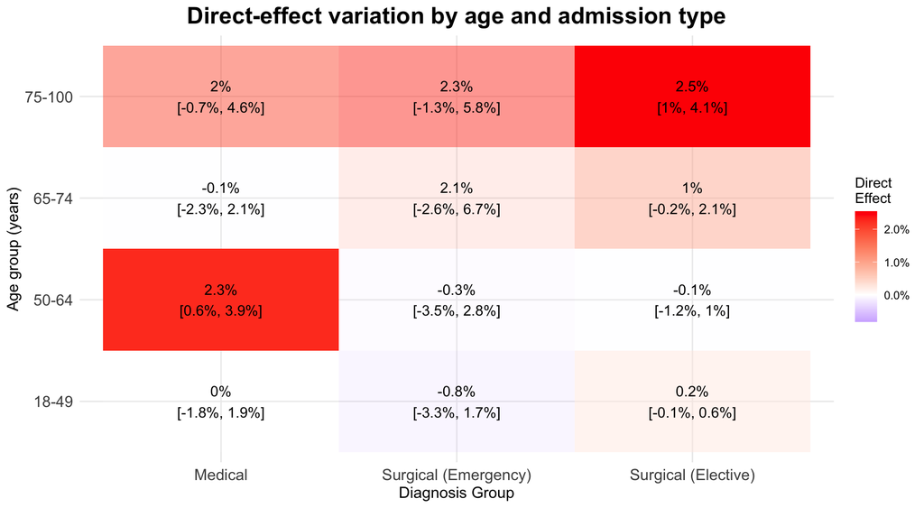

The direct effect is heterogeneous across age and admission type. Several confidence intervals are wide, so the sign cannot be established with certainty in every stratum. The plot is therefore evidence of variation and uncertainty—not a license to interpret every cell as a separate discovery.

**NoteQuestions**

1. Why can the marginal direct effect conceal clinically important variation?
2. Why must the event $E$ be defined using variables with a defensible causal position?
3. What happens to uncertainty as the events become more granular?

# 4 A possible selection explanation

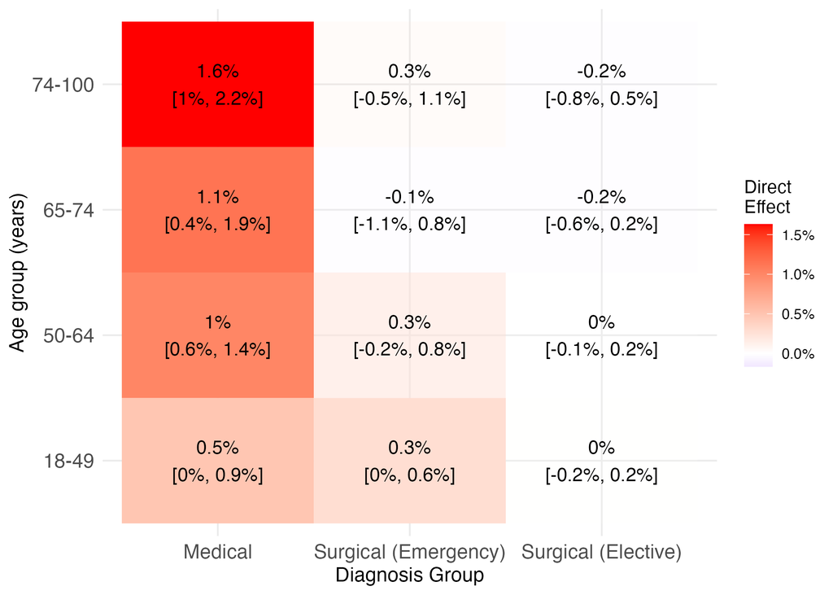

Conditional direct-effect variation in ANZICS.

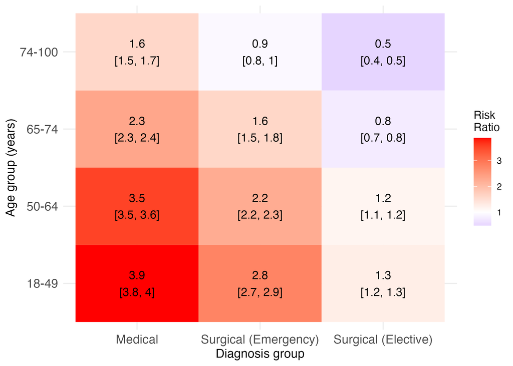

Baseline ICU-admission risk ratios.

This alignment is suggestive, not an identification result. Demonstrating a selection mechanism would require assumptions and data about ICU eligibility and admission outside the selected ICU cohort.

# 5 Takeaways

| Question | Estimand or tool | What it reveals |
| --- | --- | --- |
| Is there an observed group difference? | Total variation | The marginal mortality disparity |
| Which pathways contribute? | Direct, indirect, and spurious decomposition | Mechanisms hidden by the marginal contrast |
| How do mediator distributions differ fairly? | Monte Carlo age standardization | Group differences at a common age distribution |
| Do pathways combine non-additively? | Interaction tests | Global evidence that effects depend on other pathways |
| Does the direct effect vary? | Conditional direct effects | Variation across age and admission type |
| Could cohort construction matter? | Selection comparison | A plausible explanation requiring additional assumptions |

Moving from a marginal contrast to pathway-specific and conditional effects reveals structure that a single average cannot show. Each refinement, however, requires additional causal assumptions and usually increases statistical uncertainty.